# **Problem Definition and Data Exploration**

## **Model 7**

We will continue using the VGG16 to replace our convolutional layer. We will keep the learning rate at 0.00001 as the fifth model perfomred better than the forth model. However, we will change the batch size to 100.

```python
backend.clear_session() # Clearing backend for new model
```

```python
transfer_layer = vgg.get_layer('block5_pool')

vgg.trainable = False

x = Conv2D(filters = 32, kernel_size = 2, padding = "same" , activation = "relu")(transfer_layer.output)

x = Flatten()(x)  # Flatten the output from the 3rd block of the VGG16 model

x = Dense(256, activation = 'relu')(x)

x = Dense(128, activation = 'relu')(x)

x= Dropout(0.3)(x)

x = Dense(64, activation = 'relu')(x)

x = BatchNormalization()(x)

pred = Dense(2, activation = 'softmax')(x)

model7 = Model(vgg.input, pred) # Initializing the model
```

### **Compiling the model**

```python
# Compiling the model
adam = optimizers.Adam(learning_rate = 0.00001)
model7.compile(loss = "binary_crossentropy", optimizer = adam, metrics = ['accuracy'])
```

**using callbacks**

```python
# Adding Callbacks to the model
callbacks = [EarlyStopping(monitor = 'val_loss', patience = 2),
             ModelCheckpoint('.mdl_wts.hdf5', monitor = 'val_loss', save_best_only = True)]
```

**Fit and Train the model**

```python
history7 = model7.fit(train_generator, callbacks = callbacks,
                      validation_data= val_generator,
                      epochs = 30,
                      batch_size = 100,
                      validation_split = 0.2,
                      verbose = 1)
```

**Plot the train and validation accuracy**

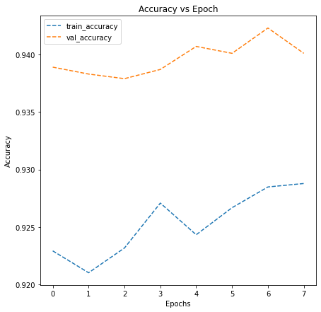

```python
# plotting the accuracies
plot_accuracy(history7)
```

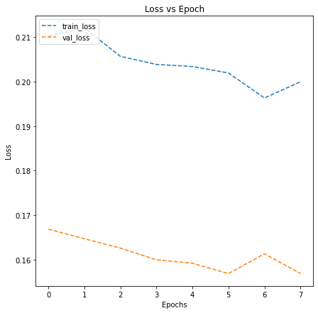

```python
plot_loss(history7)
```

### **Evaluating the model**

```python
# Evaluating the model on test data
accuracy7 = model7.evaluate(test_images, test_labels, verbose = 1)

print('\n', 'Test_Accuracy:-', accuracy7[1])
```

```
 Test_Accuracy:- 0.9223076701164246
```

**Plotting the classification report and confusion matrix**

```
              precision    recall  f1-score   support

           0       0.96      0.88      0.92      1300
           1       0.89      0.96      0.93      1300

    accuracy                           0.92      2600
   macro avg       0.93      0.92      0.92      2600
weighted avg       0.93      0.92      0.92      2600
```

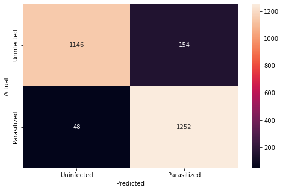

```python
# Plot the confusion matrix and generate a classification report for the model

from sklearn.metrics import classification_report

from sklearn.metrics import confusion_matrix

pred = model7.predict(test_images)

pred = np.argmax(pred, axis = 1)

y_true = np.argmax(test_labels, axis = 1)

# Printing the classification report
print(classification_report(y_true, pred))

# Plotting the heatmap using confusion matrix
cm = confusion_matrix(y_true, pred)

plt.figure(figsize = (8, 5))

sns.heatmap(cm, annot = True,  fmt = '.0f', xticklabels = ['Uninfected', 'Parasitized'], yticklabels = ['Uninfected', 'Parasitized'])

plt.ylabel('Actual')

plt.xlabel('Predicted')

plt.show()
```

#### **Observations and insights:**

This iteration of the VGG16 model performed worse than the previous one. Using a 0.00001 learning rate and 100 batch size yielded a 0.92 F1 score for the uninfected cells and a 0.93 F1 score for the parasitized cells. The overall accuracy was 92%. The model took 3 mins and 8 epochs to be trained.

# **Recommendations**

For model future improvements, we suggest trying the following:

1. Try different learning rates and batch-size when fitting the second model using the data image generator.
2. Use the Ensemble technique with multiple weak models to improve the results.

For policymakers, we suggest adopting the first model to automate and facilitate Malaria detection. However, we strongly recommend reviewing the images classified as uninfected by a physician before making the final clinical decision. This is because we do not wish for a patient to go untreated or receive delayed treatment because of a misclassification error.

```python
!jupyter nbconvert --to html Final_Submission.ipynb
```